# Lab 4

Author

Harshini Karthikeyan

# Lab 4

## Introduction and Set-up.

```r
library(tidyverse)
library(scales)
```

```r
avocado <- read_csv(here::here("supporting_artifacts", "files", "avocado.csv"))
```

#### About Data

```r
str(avocado)
```

```
spc_tbl_ [18,249 × 14] (S3: spec_tbl_df/tbl_df/tbl/data.frame)
 $ ...1        : num [1:18249] 0 1 2 3 4 5 6 7 8 9 ...
 $ Date        : Date[1:18249], format: "2015-12-27" "2015-12-20" ...
 $ AveragePrice: num [1:18249] 1.33 1.35 0.93 1.08 1.28 1.26 0.99 0.98 1.02 1.07 ...
 $ Total Volume: num [1:18249] 64237 54877 118220 78992 51040 ...
 $ 4046        : num [1:18249] 1037 674 795 1132 941 ...
 $ 4225        : num [1:18249] 54455 44639 109150 71976 43838 ...
 $ 4770        : num [1:18249] 48.2 58.3 130.5 72.6 75.8 ...
 $ Total Bags  : num [1:18249] 8697 9506 8145 5811 6184 ...
 $ Small Bags  : num [1:18249] 8604 9408 8042 5677 5986 ...
 $ Large Bags  : num [1:18249] 93.2 97.5 103.1 133.8 197.7 ...
 $ XLarge Bags : num [1:18249] 0 0 0 0 0 0 0 0 0 0 ...
 $ type        : chr [1:18249] "conventional" "conventional" "conventional" "conventional" ...
 $ year        : num [1:18249] 2015 2015 2015 2015 2015 ...
 $ region      : chr [1:18249] "Albany" "Albany" "Albany" "Albany" ...
 - attr(*, "spec")=
  .. cols(
  ..   ...1 = col_double(),
  ..   Date = col_date(format = ""),
  ..   AveragePrice = col_double(),
  ..   `Total Volume` = col_double(),
  ..   `4046` = col_double(),
  ..   `4225` = col_double(),
  ..   `4770` = col_double(),
  ..   `Total Bags` = col_double(),
  ..   `Small Bags` = col_double(),
  ..   `Large Bags` = col_double(),
  ..   `XLarge Bags` = col_double(),
  ..   type = col_character(),
  ..   year = col_double(),
  ..   region = col_character()
  .. )
 - attr(*, "problems")=<externalptr>
```

```r
dim(avocado)
```

```
[1] 18249    14
```

#### Creating Region Data Sets:

```r
region_data <-
  data.frame(region = c("California", "Midsouth", "Northeast",
                        "SouthCentral", "Southeast", "Plains",
                        "GreatLakes", "GrandRapids",
                        "NorthernNewEngland", "SouthCarolina",
                        "West" ))

state_data <-
  data.frame(region = c("California", "NewYork",
                        "South Carolina"))
```

#### Creating Subset Data Sets

```r
avocado <- avocado |> filter(region != "TotalUS")

avocado_region <- avocado |> semi_join( y = region_data,
                                        by = "region")


avocado_state <- avocado |> semi_join( y = state_data,
                                       by = "region")


avocado_metro <- avocado |>
  anti_join( y = state_data,
             by = "region") |>
  anti_join( y = region_data,
             by = "region")
```

## Exercises

**3.** Which major region sold the most organic, small Hass avocados in 2017?

```r
avocado_region|>
  filter(year == "2017", type == "organic") |>
  group_by(region)|> summarise(small = sum(`Small Bags`)) |>
  slice_max(order_by = small, n = 1 )
```

```
# A tibble: 1 × 2
  region       small
  <chr>        <dbl>
1 Northeast 7549951.
```

Northeast is the region that sold the most small, organic, Hass avocados in 2017 with 7,549,951 bags sold.

**4.** Use the `separate()` function to split the `Date` variable into year, month, and day. In which month is the highest volume of avocado sales?

```r
avocado_date <- avocado_region |>
  separate(col = Date,
           into = c(NA, "Month", "Day"))

avocado_date |>
  group_by(Month) |>
  summarise(mean = mean(`Total Volume`)) |>
  slice_max(mean, n = 1)
```

```
# A tibble: 1 × 2
  Month     mean
  <chr>    <dbl>
1 02    1942088.
```

February is the month in which the most total avocados are typically sold, with an average of 1,942,088 avocados sold.

**5.** Which metro area regions sold the most total avocados? Plot side-by-side boxplots of total volume for only the five regions with the highest averages for the `Total Volume` variable.

```r
highest_avgs <-
  avocado_metro |>
  group_by(region) |>
  summarise(mean_TV = mean(`Total Volume`)) |>
  slice_max(mean_TV, n = 5)

highest_avgs <- avocado_metro |>
  semi_join(highest_avgs, by = "region")
```

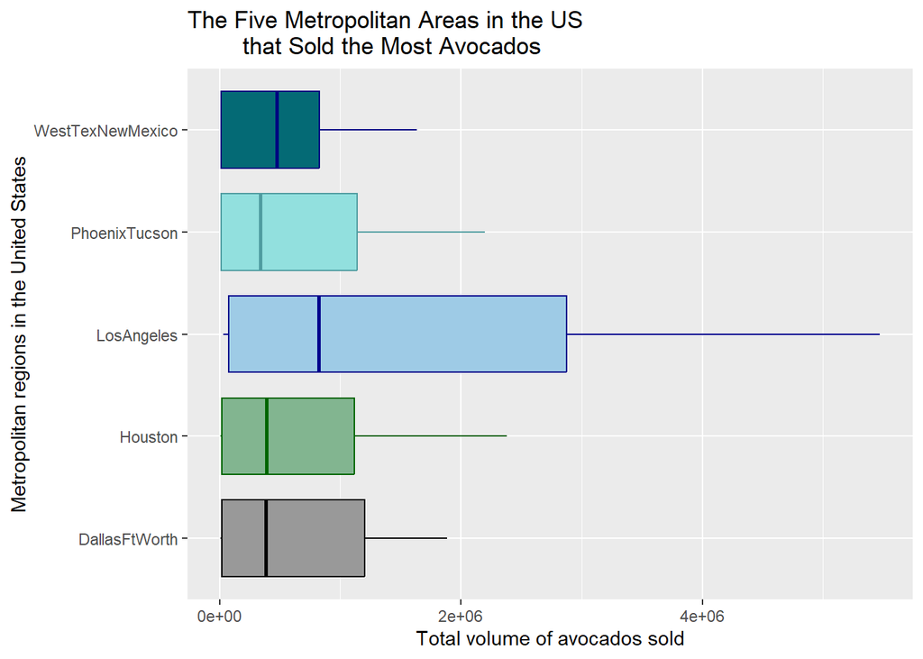

```r
cdPalette_bluegreen <- c("#999999", "#82b590",
                         "#9ecbe6", "#92e0de",
                         "#046a75")
cdPalette_outer <- c("black", "dark green",
                     "dark blue", "#509da1",
                     "navy blue")

ggplot(data = highest_avgs,
       mapping = aes( y = region,
                      x = `Total Volume`)) +
  geom_boxplot(fill = cdPalette_bluegreen,
               color = cdPalette_outer) +
  labs( y = "Metropolitan regions in the United States",
        x = "Total volume of avocados sold",
        title = "The Five Metropolitan Areas in the US
        that Sold the Most Avocados")
```

DallasFtWorth, PhoenixTucson, Houston, LosAngeles and WestTexNewMexico, sold the most total avocados.

## Reshaping

#### 6. In which regions is the price of organic versus conventional avocados most different? Support your answer with a few summary statistics and a visualization.

```r
cal_cities <- data.frame(region = c("LosAngeles",
                                    "SanDiego",
                     "Sacramento", "SanFrancisco"))
cal_cities <- avocado_metro |>
  semi_join(cal_cities, by = "region")
```

```r
cal_price_diff <-
  cal_cities |>
  group_by(region, type) |>
  summarise(mean_price = mean(AveragePrice),
            .groups = "rowwise") |>
  pivot_wider(names_from = type,
              values_from = mean_price) |>
  mutate(price_diff = abs(conventional - organic))

cal_price_diff
```

```
# A tibble: 4 × 4
  region       conventional organic price_diff
  <chr>               <dbl>   <dbl>      <dbl>
1 LosAngeles          0.976    1.46      0.479
2 Sacramento          1.27     1.97      0.695
3 SanDiego            1.06     1.73      0.673
4 SanFrancisco        1.40     2.21      0.814
```

```r
cal_price_diff|> slice_max(price_diff, n = 1)
```

```
# A tibble: 1 × 4
  region       conventional organic price_diff
  <chr>               <dbl>   <dbl>      <dbl>
1 SanFrancisco         1.40    2.21      0.814
```

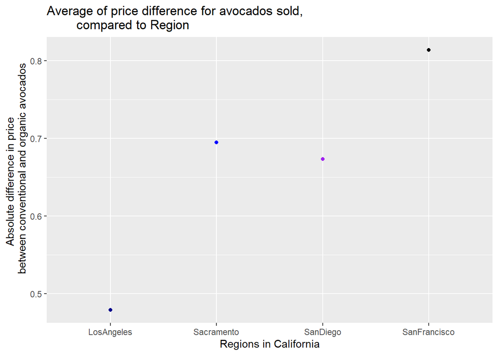

```r
cdPalette_bluepurple <- c("dark blue",
                         "blue", "purple",
                         "black")

ggplot(data = cal_price_diff,
        mapping = aes(x = region,
                      y = price_diff)) +
  geom_point(color = cdPalette_bluepurple) +
  labs( x = "Regions in California",
        y = "Absolute difference in price
        between conventional and organic avocados",
        title = "Average of price difference for avocados sold,
        compared to Region")
```

San Francisco is the Californian region which as the greatest difference in mean price for organic versus conventional avocados. As shown by the graph, the table, and the slice_max function.

#### 7. Recreate the plot.

The plot is shown below. The fill order, and therefore the colors are flipped, but the result is the same otherwise.

```r
cal_prop <- cal_cities |>
  select(region, type, `4046`,
         `4225`,  `4770`
         ) |>
  group_by(region, type
           )|>
  summarise(small = `4046`,
            large = `4225`,
            extra_large = `4770`,
            .groups = "rowwise"
            ) |>
  mutate(total = (small + large + extra_large),
         small = (small / total),
         large = (large / total),
         extra_large = (extra_large / total)
         ) |>
  pivot_longer(cols = c("small", "large",
                        "extra_large"),
               names_to = "Avocado_Size",
               values_to = "Proportion_of_Total")
```

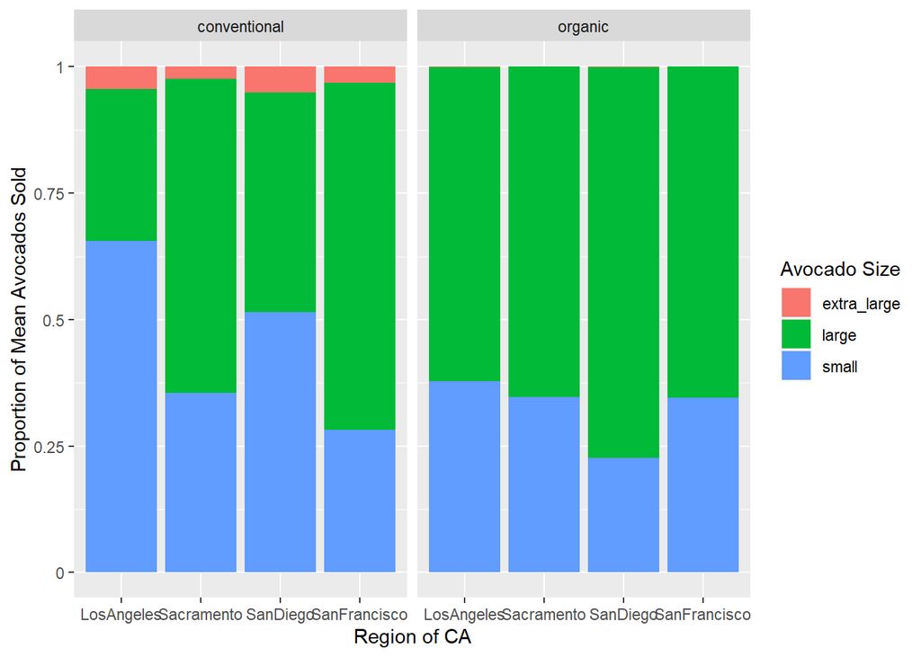

```r
#Source:
# https://r-graph-gallery.com/48-grouped-barplot-with-ggplot2.html
# used for y, and stat arguments
# https://stackoverflow.com/questions/27433798/how-can-i-change-the-y-axis-figures-into-percentages-in-a-barplot
# used ofr scale_y_continuous

ggplot(data = cal_prop,
       mapping = aes(x = region,
                     fill = Avocado_Size,
                     y = Proportion_of_Total )) +
  geom_bar(stat = "identity") +
  facet_wrap(vars(type)) +
  scale_y_continuous(labels = function(x) paste0(round(x/169,
                                                       3)),
                     breaks = seq(0, 169, 42.25)) +
  labs( x = "Region of CA",
        y = "Proportion of Mean Avocados Sold",
        fill = "Avocado Size")
```

# Revisions

#### Set-Up/Formatting:

For the first two code chunks I added in “message = FALSE” to remove the message. I organized the code chunks better by titling each code chunk with text above it.

#### Creating region data sets:

I misunderstood and had thought that metro and cities were required to be two different data sets and then made an extra data set that I never even used. So I have now fixed that and only used an anti_join.

I also deleted the Total_Us data frame and removed TotalUS from my data using filter() instead of anti_join(). I think I used that previously because I had emphasized using only those new functions we had learned and over-complicated it.

I made a different data set for the three states in the data set as they are neither cities nor major regions.

I removed the “(#|output:FALSE)” entirely as it was no longer necessary

#### Creating subset data sets:

This was more of an error due to the fact that I had previously thought that an ‘x =’ argument was necessary, but with the pipeline it isn’t. I had gotten errors. Not knowing what was wrong, I had separated them into two lines of code. The pipeline with the anti_join and semi_join functions has been fixed now.

#### Questions

3. For this one I didn’t properly read the question and notice the type specification of organic. I also failed to recognize that there were multiple sales record for each year. I created a summary table that more accurately represents what the question was asking for now.
5. This was a simpler fix. I had not realized the “==” was detrimental with a vector of columns, but I will not use it again. The filtering join also made it so I didn’t need to type out the names.
   1. I tried a different graph title.
6. Another easier fix, same issue as stated in number 5.
   1. For the .groups argument, I received a message that said I would be able to fix an issue due to summarizing after grouping by using either the .groups argument or the group_by function. I didn’t want to use the group_by function twice in the pipeline, so I looked up the summarize function in R’s help section.
7. I changed out the columns names, so the data represented the number of avocados sold and not the bags. My x and y axes labels were also flipped for some reason, but I changed those to be correct. I used the scale_y_continuous function to make the y axis proportions.